# OMRRAY001 JULIA ASSIGNMENT 2

## Exercise 6.2

### 6.2a (ii)

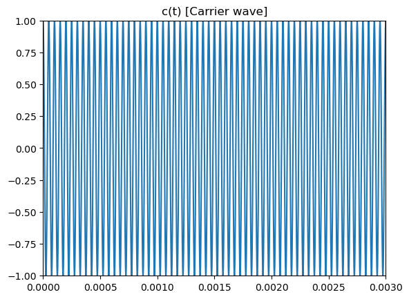

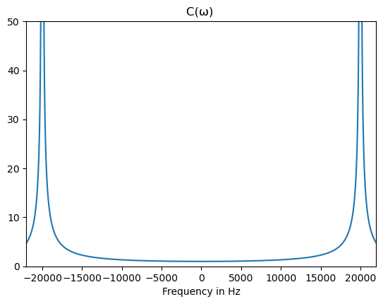

```julia
# Plotting of carrier wave
figure();plot(t,c);PyPlot.title("c(t) [Carrier wave]");plt.axis([0, 0.003, -1, 1]);


# Plotting of carrier wave's fft after fftshift
figure(figsize=(6.4,4.5)); PyPlot.margins(x=-0.4,y=0.1); plot(f_axisSh, fftshift(abs.(C)),"-"); xlabel("Frequency in Hz");
plt.axis([-22000, 22000, 0, 50]);PyPlot.title("C(ω) ");
```

### 6.2a (iii)

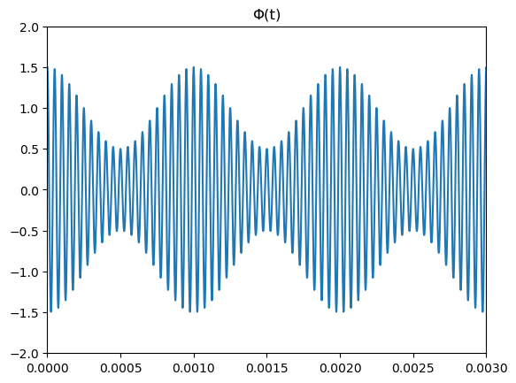

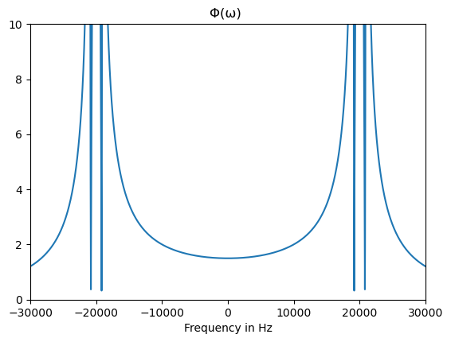

```julia
# Plotting of amplitude modulated carrrier wave
figure();plot(t,ϕ);PyPlot.title("Φ(t)");plt.axis([0, 0.003, -2, 2]);


# Plotting of amplitude modulated carrier wave's fft after fftshift
figure(figsize=(6.4,4.5)); PyPlot.margins(x=-0.4,y=0.1); plot(f_axisSh, fftshift(abs.(Φ)),"-"); xlabel("Frequency in Hz");
plt.axis([-30000, 30000, 0, 10]);PyPlot.title("Φ(ω) ");
```

Sidebands are at roughly 19 kHz and 21kHz

#### Answers

- Modulation index is 0.5

### 6.2b (i)

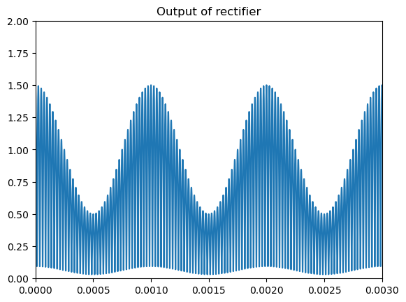

```julia
output_of_rectifier = abs.(ϕ);
output_of_rectifierF=fft(output_of_rectifier)
#BPF prep
CutoffL=20; #lower cutoff frequency
CutoffH=5000; #upper cutoff frequency

ΔNL= ceil(Int,(CutoffL/(8*pi*N))*N) #find cuttoff indexes for array with N values
ΔNH= floor(Int,(CutoffH/(8*pi*N))*N) #find cuttoff indexes for array with N values

#Demodulation step 2: applying LPF to Φ(ω) ∗ C(ω)
bpfOR=output_of_rectifierF;
bpfOR[1:ΔNL].=0; bpfOR[ΔNH:N-ΔNH].=0; bpfOR[N-ΔNL:N].=0;

output_of_filter = real( ifft( bpfOR ));

# Plotting of the rectifier's output
figure();plot(t,output_of_rectifier);PyPlot.title("Output of rectifier");plt.axis([0, 0.003, 0, 2]);
```

### 6.2b (ii)

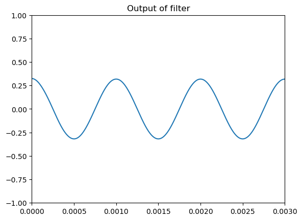

```julia
# Plotting of the filters's output in the time domain
figure();plot(t,output_of_filter);PyPlot.title("Output of filter");plt.axis([0, 0.003, -1, 1]);
```

### 6.2c (i)

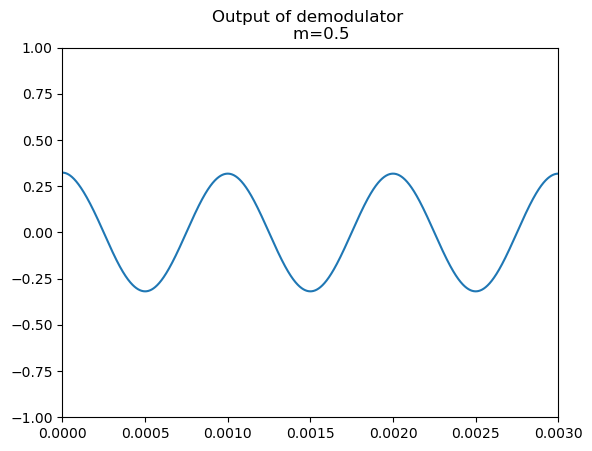

```julia
# Importing useful libraries
using PyPlot
using FFTW

# Create array for t + related variables
Δt=0.000001;
t=0:Δt:0.04;
N = length(t)
Δf = 1/(N*Δt)  # spacing in frequency domain


# Create waves/signals  + related variables
A=1
k=0.5
fc=20000;
fm=1000;
f=k.*cos.(2π*fm.*t)
c=cos.(2π*fc.*t)
ϕ=(f.+A).*c


# Fourier Transforms of each wave
F = fft(f);
C=fft(c);
Φ=fft(ϕ);

output_of_rectifier = abs.(ϕ);
output_of_rectifierF=fft(output_of_rectifier)
#BPF prep
CutoffL=20; #lower cutoff frequency
CutoffH=5000; #upper cutoff frequency

ΔNL= ceil(Int,(CutoffL/(8*pi*N))*N) #find cuttoff indexes for array with N values
ΔNH= floor(Int,(CutoffH/(8*pi*N))*N) #find cuttoff indexes for array with N values

#Demodulation step 2: applying LPF to Φ(ω) ∗ C(ω)
bpfOR=output_of_rectifierF;
bpfOR[1:ΔNL].=0; bpfOR[ΔNH:N-ΔNH].=0; bpfOR[N-ΔNL:N].=0;

output_of_filter = real( ifft( bpfOR ));




# Plotting of the filters's output in the time domain
figure();plot(t,output_of_filter);PyPlot.title("Output of demodulator
    m=0.5");plt.axis([0, 0.003, -1, 1]);
```

### 6.2c (ii)

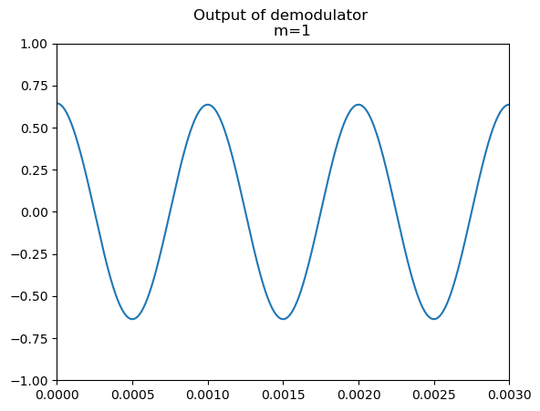

```julia
# Importing useful libraries
using PyPlot
using FFTW

# Create array for t + related variables
Δt=0.000001;
t=0:Δt:0.04;
N = length(t)
Δf = 1/(N*Δt)  # spacing in frequency domain


# Create waves/signals  + related variables
A=1
k=1
fc=20000;
fm=1000;
f=k.*cos.(2π*fm.*t)
c=cos.(2π*fc.*t)
ϕ=(f.+A).*c


# Fourier Transforms of each wave
F = fft(f);
C=fft(c);
Φ=fft(ϕ);

output_of_rectifier = abs.(ϕ);
output_of_rectifierF=fft(output_of_rectifier)
#BPF prep
CutoffL=20; #lower cutoff frequency
CutoffH=5000; #upper cutoff frequency

ΔNL= ceil(Int,(CutoffL/(8*pi*N))*N) #find cuttoff indexes for array with N values
ΔNH= floor(Int,(CutoffH/(8*pi*N))*N) #find cuttoff indexes for array with N values

#Demodulation step 2: applying LPF to Φ(ω) ∗ C(ω)
bpfOR=output_of_rectifierF;
bpfOR[1:ΔNL].=0; bpfOR[ΔNH:N-ΔNH].=0; bpfOR[N-ΔNL:N].=0;

output_of_filter = real( ifft( bpfOR ));




# Plotting of the filters's output in the time domain
figure();plot(t,output_of_filter);PyPlot.title("Output of demodulator
    m=1");plt.axis([0, 0.003, -1, 1]);
```

### 6.2c (iii)

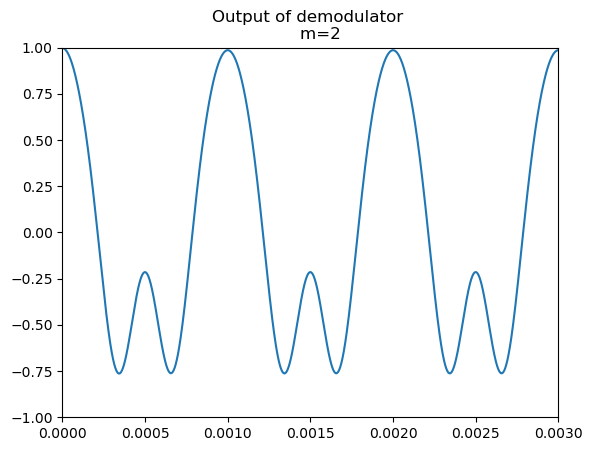

```julia
# Importing useful libraries
using PyPlot
using FFTW

# Create array for t + related variables
Δt=0.000001;
t=0:Δt:0.04;
N = length(t)
Δf = 1/(N*Δt)  # spacing in frequency domain


# Create waves/signals  + related variables
A=1
k=2
fc=20000;
fm=1000;
f=k.*cos.(2π*fm.*t)
c=cos.(2π*fc.*t)
ϕ=(f.+A).*c


# Fourier Transforms of each wave
F = fft(f);
C=fft(c);
Φ=fft(ϕ);

output_of_rectifier = abs.(ϕ);
output_of_rectifierF=fft(output_of_rectifier)
#BPF prep
CutoffL=20; #lower cutoff frequency
CutoffH=5000; #upper cutoff frequency

ΔNL= ceil(Int,(CutoffL/(8*pi*N))*N) #find cuttoff indexes for array with N values
ΔNH= floor(Int,(CutoffH/(8*pi*N))*N) #find cuttoff indexes for array with N values

#Demodulation step 2: applying LPF to Φ(ω) ∗ C(ω)
bpfOR=output_of_rectifierF;
bpfOR[1:ΔNL].=0; bpfOR[ΔNH:N-ΔNH].=0; bpfOR[N-ΔNL:N].=0;

output_of_filter = real( ifft( bpfOR ));




# Plotting of the filters's output in the time domain
figure();plot(t,output_of_filter);PyPlot.title("Output of demodulator
    m=2");plt.axis([0, 0.003, -1, 1]);
```

### Answers

I can conclude that the m>1 case creates distortion due to the signal crossing the zero line

## Exercise 6.3

### 6.3

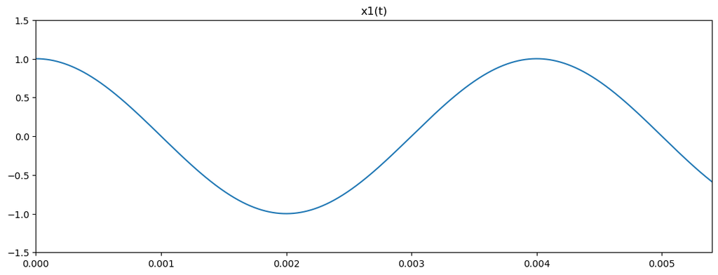

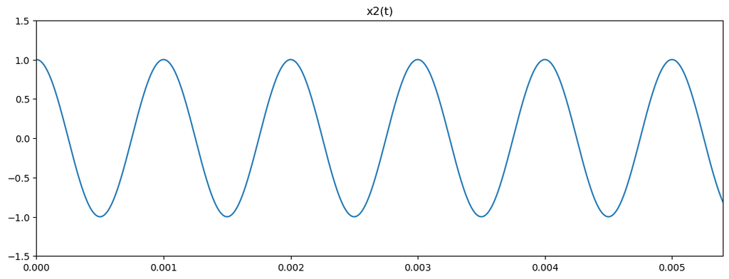

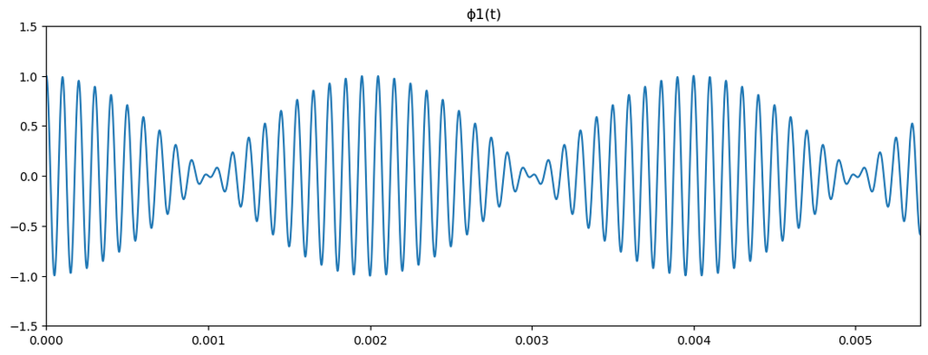

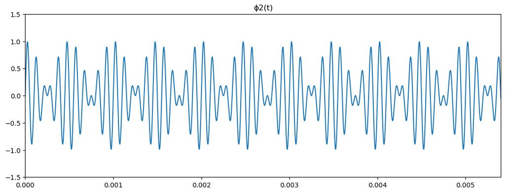

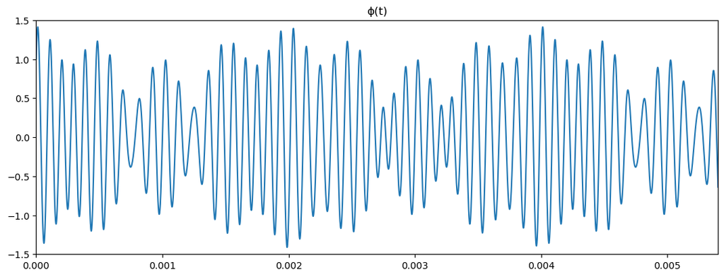

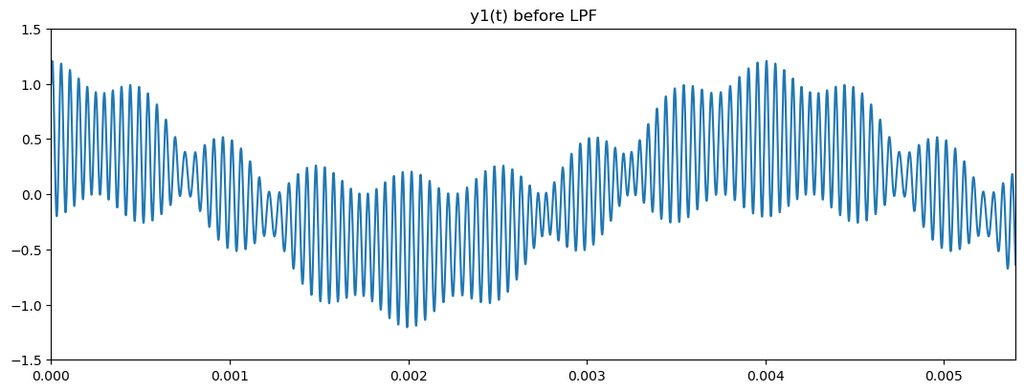

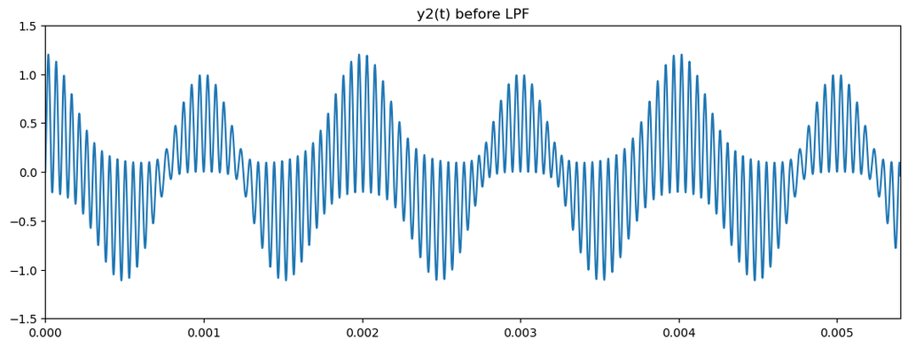

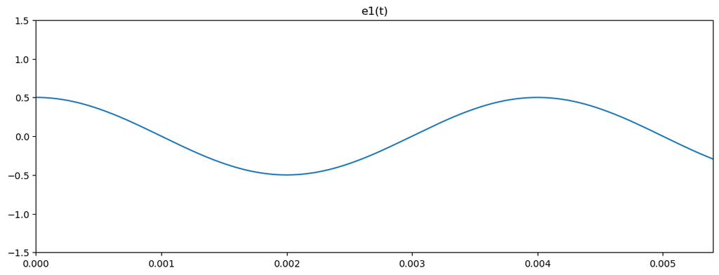

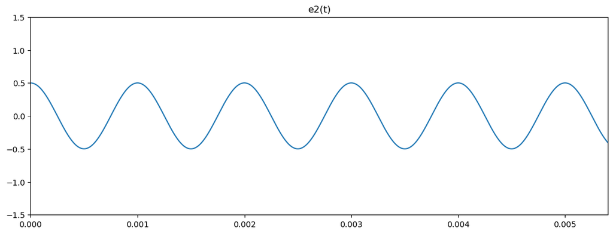

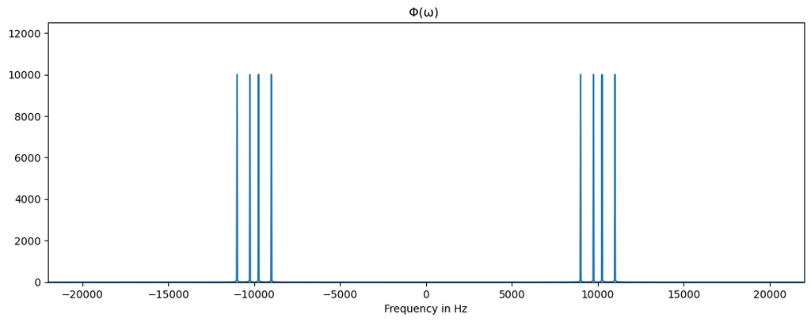

```julia
# Importing useful libraries
using PyPlot
using FFTW

# Create array for t + related variables
Δt=0.000001;
t=0:Δt:0.04;
N = length(t)
Δf = 1/(N*Δt)  # spacing in frequency domain


# Create waves/signals  + related variables
fc=10000;
fm1=250;
fm2=1000;
x1=cos.(2π*fm1.*t)
x2=cos.(2π*fm2.*t)
c=cos.(2π*fc.*t)
s=sin.(2π*fc.*t)
ϕ1=x1.*c
ϕ2=x2.*s
ϕ=ϕ1+ϕ2




# Fourier Transforms of each relevant wave
Φ=fft(ϕ);

#create array of freq values stored in f_axis. First element maps to 0Hz (for fft)
f_axis = (0:N-1)*Δf;
#Label the frequency axis in Hz
N = length(t);
Δf = 1/(N*Δt)  # spacing in frequency domain

#create array of freq values stored in f_axis. (for fftshift)
if mod(N,2)==0    # case N even
    f_axisSh = (-N/2:N/2-1)*Δf;
else   # case N odd
    f_axisSh = (-(N-1)/2 : (N-1)/2)*Δf;
end


# Plotting of modulating waves + ϕs
figure(figsize=(13,4.5)); plot(t,x1); PyPlot.title("x1(t)"); plt.axis([0, 0.0054, -1.5, 1.5]);
figure(figsize=(13,4.5)); plot(t,x2); PyPlot.title("x2(t)"); plt.axis([0, 0.0054, -1.5, 1.5]);
figure(figsize=(13,4.5)); plot(t,ϕ1); PyPlot.title("ϕ1(t)"); plt.axis([0, 0.0054, -1.5, 1.5]);
figure(figsize=(13,4.5)); plot(t,ϕ2); PyPlot.title("ϕ2(t)"); plt.axis([0, 0.0054, -1.5, 1.5]);
figure(figsize=(13,4.5)); plot(t,ϕ); PyPlot.title("ϕ(t)"); plt.axis([0, 0.0054, -1.5, 1.5]);






#Demodulation step 1: multipliying ϕ with carrier
ϕc=ϕ.*c
ΦC=fft(ϕc);
ϕs=ϕ.*s
ΦS=fft(ϕs);


#LPF prep
Cutoff1=500; #cutoff frequency
ΔN1= ceil(Int,(Cutoff1/(8*pi*N))*N) #find cuttoff indexes for array with N values
Cutoff2=1500; #cutoff frequency
ΔN2= floor(Int,(Cutoff2/(8*pi*N))*N) #find cuttoff indexes for array with N values

#Demodulation step 2: applying LPF to Φ(ω) ∗ C(ω)
lpfΦC=ΦC
lpfΦC[ΔN1:N-ΔN1].=0;
lpfΦS=ΦS
lpfΦS[ΔN2:N-ΔN2].=0;




#Demodulation step 3: apply inverse fft to LPF[ Φ(ω) ∗ C(ω) ] to get 0.5f(t) signal
fd1 = real(ifft(lpfΦC))
fd2 = real(ifft(lpfΦS))


# Plotting of reconstructed modulating waves after lpf
figure(figsize=(13,4.5)); plot(t,real(ϕc)); PyPlot.title("y1(t) before LPF");  plt.axis([0, 0.0054, -1.5, 1.5]);

figure(figsize=(13,4.5)); plot(t,real(ϕs)); PyPlot.title("y2(t) before LPF"); plt.axis([0, 0.0054, -1.5, 1.5]);


# Plotting of reconstructed modulating waves after lpf
figure(figsize=(13,4.5)); plot(t,real(fd1)); PyPlot.title("e1(t)");  plt.axis([0, 0.0054, -1.5, 1.5]);

figure(figsize=(13,4.5)); plot(t,real(fd2)); PyPlot.title("e2(t)"); plt.axis([0, 0.0054, -1.5, 1.5]);


# Plotting of signal Φ(t) wave's fft after fftshift
figure(figsize=(13,4.5)); PyPlot.margins(x=-0.4,y=0.1); plot(f_axisSh, fftshift(abs.(Φ)),"-"); xlabel("Frequency in Hz");
plt.axis([-22000, 22000, 0, 12500]);PyPlot.title("Φ(ω) ");
```

### 6.3 (2)

The transmitted waveform would have a bandwidth of B2.

### 6.3 (3)

The higher the phase difference (up to 90 degrees) the greater amount of crosstalk between the 'channels' (for the lack of a better term that I can think of).

# References

A substantial amount of the code in this reporrt was borrowed from the slides from the previous Julia Assignments. It would not be practical to determine which exact lines make use of that code.